# Final Paper

STOR 320.01 Group 4

2023-04-25

## Introduction:

> The quality of life has significantly improved worldwide over the last two decades due to major breakthroughs in the healthcare and pharmaceutical industries. Diseases that were once deemed fatal have become treatable as a result of new therapeutics and surgical procedures. Consequently, populations across the world are healthier today compared to any period in history. Life expectancy is a measure of the average number of years a person is expected to live based on a variety of factors such as gender, ethnicity, and occupation. This metric is a key indicator of a population’s overall health and typically used as a measure of the quality of life in a country. Based on the research conducted by The World Health Organization (WHO), the world’s life expectancy has increased from 66.2 years to 73.2 years since 2000, which is a 10% increase averaged amongst all people from different parts of the world. Most countries hold confidence and refer to the data collected by The World Health Organization (WHO), which has served as the global leader regarding this topic for the last 80 years. Not only does life expectancy provide information about the longevity of a population, it also gives lawmakers the necessary information to create informed healthcare policies that actually benefit their citizens. For example, a country with a high life expectancy might be able to reallocate resources away from healthcare and towards something like education. In contrast, a country with a low life expectancy would benefit from further investment in healthcare and new medical technology.

> Another important national health metric that is measured by the WHO is the Human Development Index (HDI). In short, the HDI is a complex statistic, created in 1990, that measures a country’s development in three overarching categories: health, education, and income. Analysis of the data from the World Health Organization prompted us to develop our first question: How accurately can we predict Human Development Index (HDI) by combining models for predicting Life Expectancy and GDP? A logical hypothesis is that a country with a higher life expectancy and higher GDP per capita would have a higher HDI. However, we wanted to examine this question in detail by considering the weight of the variables that best predict Life Expectancy and GDP.

> We also wanted to investigate which variables most heavily impact the development status of countries as the WHO lists the development status of every country they monitor. In the dataset, a country is marked as either “developed” or “developing”. It is easy to imagine the things that make a country developed: political stability, high resource accessibility, and a strong international reputation. However, according to the United Nations Statistical Division, there is no actual established criteria that defines a “developed” nation nor distinguishes the categorical designation of a “developing” nation. This leads us to our second overarching question: How accurately can a country’s development status be predicted based on other variables in the dataset? We wanted to analyze the cutoff criteria between developed and developing nations through answering this question. We know a high life expectancy is a necessary component, but how high must it be? How wealthy must the nation be? How well-educated? These answers can be achieved by creating models that incorporate both the health-related and money-related variables. Ultimately, the results of analyzing these questions will allow us to determine the weight of life expectancy on a “developed” designation as a whole, or discover if other variables should be considered to define status.

> While many countries have access to ample resources, there is still a significant discrepancy in access to resources throughout the world. The investigation of our two questions is important to highlight possible ways for countries to assess and improve quality of life. This type of assessment would allow governments around the world to reevaluate their policies and allocate resources accordingly. The ultimate purpose of our analysis is to promote better understanding of what measurable statistics can define a standard of living in the context of a country’s development progression and eventually bridge the life expectancy gap across the world.

## Data:

> After checking multiple open-source dataset websites, we found that Kaggle contained the most easily accessible and complete datasets for the topics we were seeking to study. Considering this, we utilized this resource to mine data, which was narrowed to a life expectancy dataset from 2018. From the description, we found that it was collected by an individual who web scraped it from the World Health Organization data repository website and the United Nations website. From there, we looked at each of the variables in depth. Upon investigation, we recognized some initial issues with the data, and specifically found that, for some of the variables, the values listed on the WHO website did not align with the values listed in the original dataset. In order to address this, we checked many of the values on the WHO and UN websites for accuracy. We found that many of the units stated on the Kaggle website and in our dataset may have been incorrect. For example, the `BMI` variable had values ranging from 1 to 87.3, which are both extremely unrealistic. In order to verify the validity of the variables in question, we made several simple scatter plots comparing the distribution and found that they still behaved in an expected way. Considering this, we continued using all of the variables and found that they aided in improving modeling accuracy later.

> After selecting our data and the variables we were going to include, the only data cleaning we had to do was rename variables in such a way that made them easier to work with. A summary table of the variables and their meaning is shown below:

| Variables | Meaning | Average |
| --- | --- | --- |
| Country | Country Name | NA |
| Year | Year | 2007.518720 |
| Status | Classification as Developed or Developing | NA |
| Life_Expectancy_Years | Life Expectancy in Years | 69.22493 |
| Adult_Mortality | The number of individuals who died between 15 and 60 years of age per 1000 population. | 164.7964 |
| Infant_Deaths | Number of Infant Deaths | 30.30395 |
| Alcohol | Recorded per capita (ages 15+) consumption (in liters of pure alcohol) | 4.602861 |
| Percent_Expenditure | Expenditure on Health as a Percentage of Gross Domestic Product Per Capita(%) | 738.2513 |
| Hepatitis_B | Hepatitis B (HepB) Immunization Coverage Among 1-year-olds (%) | 80.94046 |
| Measles | Number of Reported Measles Cases | 2,419.592 |
| BMI | Average Body Mass Index of Entire Population on 0-100 Scale | 38.32125 |
| Under_Five_Deaths | Number of Under-Five Deaths per 1000 Population | 42.03574 |
| Polio | Polio (Pol3) Immunization Coverage Among 1-year-olds (%) | 82.55019 |
| Total_Expenditure | General Government Expenditure on health as a percentage of total government expenditure (%) | 5.93819 |
| Diphtheria | Diphtheria Tetanus Toxoid and Pertussis (DTP3) Immunization coverage among 1-year-olds (%) | 82.32408 |
| HIV/AIDS | Deaths Per 1000 Live Births HIV/AIDS (0-4 years) | 1.742103 |
| GDP | Gross Domestic Product Per Capita (in USD) | 7,483.158 |
| Population | Population of the Country | 12,753,375 |
| Underweight_(10-19) | Prevalence of Thinness Among Children and Adolescents for Ages 10 to 19 (% ) | 4.839704 |
| Underweight_(5-9) | Prevalence of Thinness Among Children for Ages 5 to 9(%) | 4.870317 |
| HDI | Human Development Index in Terms of Income Composition of Resources (Index ranging from 0 to 1) | 0.6275511 |
| Schooling | Number of Years of Schooling | 11.99279 |

> Within our dataset, it is important to note that each observation represents a country in a certain year. There are multiple observations for each country that fall between the years 2000 and 2015 which allows us to track changes in vaccination rates, life expectancy, and other measures over the course of more than a decade. This also allowed us to get a better idea about which variables would be the best predictors for country status by allowing us to see what changed and determine which, if any, of those changes led to status reclassification for certain countries. The sample contains data for all of the countries in the world, and it contains 1,649 observations.

> Within our data, the main topic is human development and the variables that influence it. Considering this, we tracked how life expectancy changed for each country over time and placed it in a map to give a general idea about the effect time has on life expectancy by country.

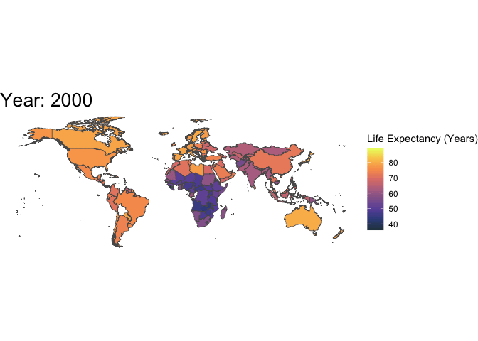

## Results

### Question 1:

> To answer our first question - How accurately can we predict Human Development Index (HDI) by using combined models for predicting Life Expectancy and GDP - multiple models were required to figure out how to best predict life expectancy and GDP per capita data. Our first step to answering this question was to find the best model for both life expectancy and GDP per capita. We first removed the `HDI` variable from our dataset because ultimately we were trying to predict HDI, therefore, it didn’t make sense to include it in our intermediate life expectancy and GDP models. We also decided to remove the `Country` variable as its potential complications outweighed any benefits it may have added to the prediction accuracy. From there, we created five models for both `GDP` and `Life Expectancy` with the intention of selecting the best one for each variable.

> The five models we chose to include were an empty model, a full model using all variables except the two discussed above, and three full models, which utilized a penalized maximum likelihood method via the `glmnet` function from the `glmnet` package. These three models included single, 2-way, and 3-way interactions between variables respectively. It was important for us to use the `glmnet` function because it eliminates unnecessary variables by optimizing the model and converging unnecessary variables’ coefficients to 0 (and thus not including them in the final model). This allowed us to create the simplest version of each model. Additionally, we decided to include both the 2-way and 3-way interactions between variables because of the nature of our dataset. Our dataset includes many variables that are inherently dependent on one another so we thought it would be naive of us to view them all as independent in our modeling. When finding predictions for each of our models, we utilized a 10 k-fold cross-validation method to create accurate predictions and utilize our entire dataset. The table shown below lists the results from each model and ranks them based on the Root Mean Squared Error (RMSE):

[output not shown]

> Given that there were 157 variables in our three-way interaction combined model, we decided to take a more straightforward approach by using this same combining technique but with a simple linear regression model. Again, we found the coefficients from both the GDP model and the Life Expectancy model and took an average between the two of them to calculate the coefficients for our combined models. The table below displays the 25 most important scaled coefficients from our original approach - using the three-way interaction model - and also includes the coefficients from our second approach using simple linear regression models:

| Coefficients (Scaled) by modeling techquie Parameter | Coefficients (Scaled) by modeling techquie Life Expectancy Coefficients | Coefficients (Scaled) by modeling techquie GDP Coefficients | Coefficients (Scaled) by modeling techquie Combined Models | Coefficients (Scaled) by modeling techquie HDI Coefficients |
| --- | --- | --- | --- | --- |
| **Best preforming Life Expectancy and GDP models** |  |  |  |  |
| Infant_Deaths:HIV_ADIS:Schooling | 0.0292356 | 0.0000000 | 0.0146178 | 2.7886276 |
| percentage_expenditure:Under_Five_Deaths:HIV_ADIS | 0.1368634 | 0.0000000 | 0.0684317 | 0.5200582 |
| percentage_expenditure:Underweight_child | 0.0000000 | -0.0022288 | -0.0011144 | 0.4990137 |
| GDP:StatusDeveloping | 0.1580968 | 0.0000000 | 0.0790484 | 0.4726161 |
| Alcohol:percentage_expenditure:Underweight_to_adult | 0.0000000 | -0.0182521 | -0.0091260 | 0.4437366 |
| percentage_expenditure:Schooling:StatusDeveloping | -0.0580297 | 0.0000000 | -0.0290148 | 0.4247649 |
| Life_Expectancy_Years | 0.0000000 | 0.0093644 | 0.0046822 | 0.4061130 |
| Int | 0.2541883 | -0.1070033 | 0.0735925 | 0.2929707 |
| Underweight_child | -0.0738263 | 0.0000000 | -0.0369132 | 0.2759381 |
| Adult_Mortality:Measles:StatusDeveloping | -0.0036224 | 0.0000000 | -0.0018112 | 0.2627087 |
| percentage_expenditure:HIV_ADIS:StatusDeveloping | 0.0078432 | 0.0000000 | 0.0039216 | 0.2509347 |
| Life_Expectancy_Years:percentage_expenditure:Underweight_child | 0.0000000 | -0.0338667 | -0.0169334 | 0.2167920 |
| Schooling | 0.1675389 | 0.0672743 | 0.1174066 | 0.2029625 |
| Year:percentage_expenditure:Polio | 0.0000000 | 0.0031786 | 0.0015893 | 0.1920171 |
| Year:GDP:StatusDeveloping | 0.0145360 | 0.0000000 | 0.0072680 | 0.1476848 |
| BMI:Schooling:StatusDeveloping | -0.0847263 | 0.0000000 | -0.0423631 | -0.1390796 |
| StatusDeveloping | -0.1638873 | -0.0600014 | -0.1119443 | -0.1554695 |
| Alcohol:Underweight_child | -0.0481160 | 0.0000000 | -0.0240580 | -0.1690640 |
| Adult_Mortality:Measles | -0.0018710 | 0.0000000 | -0.0009355 | -0.2347290 |
| percentage_expenditure:StatusDeveloping | 0.1451688 | 0.0518468 | 0.0985078 | -0.2669230 |
| Underweight_to_adult | -0.0545213 | 0.0000000 | -0.0272607 | -0.2673062 |
| Alcohol:percentage_expenditure:Underweight_child | 0.0000000 | -0.0109204 | -0.0054602 | -0.4532787 |
| GDP:Schooling:StatusDeveloping | -0.0858927 | 0.0000000 | -0.0429463 | -0.5135581 |
| percentage_expenditure:Underweight_to_adult | 0.0000000 | -0.0340135 | -0.0170068 | -0.6868934 |
| Under_Five_Deaths:HIV_ADIS:Schooling | 0.0344969 | 0.0000000 | 0.0172484 | -2.6758982 |
| **Linear regression models using all variables** |  |  |  |  |
| Life_Expectancy_Years | 0.0000000 | 0.0209449 | 0.0104725 | 0.3811583 |
| Schooling | 0.4414187 | 0.0416706 | 0.2415446 | 0.3754171 |
| Infant_Deaths | 1.2393789 | 0.0246306 | 0.6320048 | 0.1355049 |
| Alcohol | -0.0268940 | 0.0128201 | -0.0070369 | 0.1354873 |
| GDP | 0.0669461 | 0.0000000 | 0.0334730 | 0.1050747 |
| Year | -0.0422430 | 0.0297551 | -0.0062440 | 0.0997835 |
| HIV_ADIS | -0.2416594 | 0.0067761 | -0.1174417 | 0.0801285 |
| Diphtheria | 0.0522214 | -0.0030930 | 0.0245642 | 0.0548133 |
| BMI | 0.0829316 | -0.0042640 | 0.0393338 | 0.0372893 |
| Status | -0.0971731 | -0.0540123 | -0.0755927 | 0.0193612 |
| Underweight_child | -0.0244036 | -0.0090347 | -0.0167192 | 0.0063330 |
| Measles | -0.0120413 | 0.0009923 | -0.0055245 | 0.0063105 |
| Polio | 0.0160685 | 0.0104111 | 0.0132398 | 0.0016854 |
| Adult_Mortality | -0.2319272 | 0.0033015 | -0.1143129 | 0.0003840 |
| Population | -0.0057592 | -0.0041840 | -0.0049716 | -0.0058479 |
| Int | 0.0932115 | -0.0758385 | 0.0086865 | -0.0170367 |
| Hepatitis_B | -0.0145678 | 0.0027666 | -0.0059006 | -0.0203451 |
| Total_Expenditure | 0.0185027 | -0.0122363 | 0.0031332 | -0.0316118 |
| Underweight_to_adult | -0.0148802 | 0.0019511 | -0.0064646 | -0.0469688 |
| percentage_expenditure | 0.0479992 | 0.8308973 | 0.4394482 | -0.0837964 |
| Under_Five_Deaths | -1.2525611 | -0.0181684 | -0.6353647 | -0.0855828 |

> Additionally, the following graphs highlight the differences in the combined model and the HDI model between the two modeling techniques:

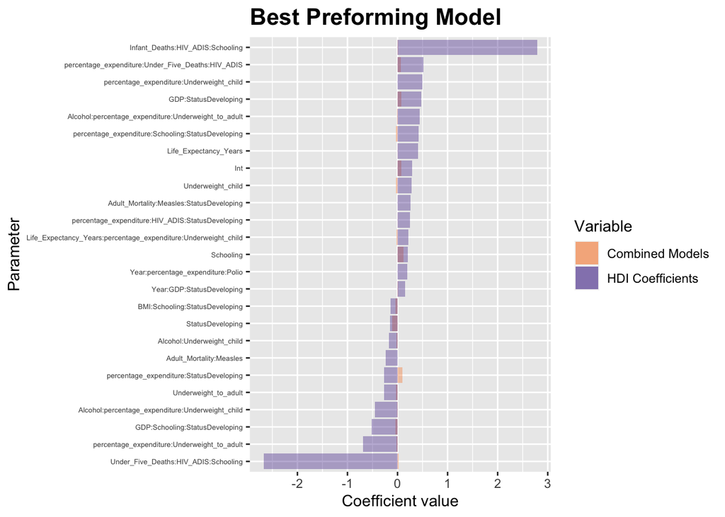

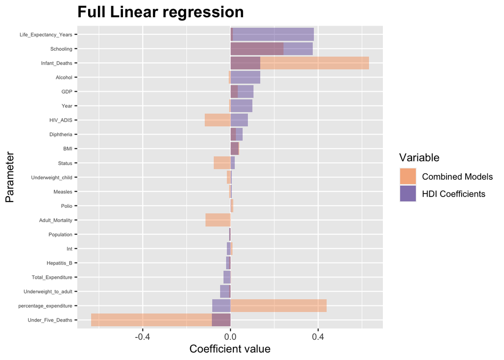

> When combining the two models for GDP and Life Expectancy, we found a simple linear regression modeling technique predicted HDI better than the 3-way interaction modeling technique we originally used. This was interesting considering that individually, the full linear regression models were less accurate in predicting GDP and Life Expectancy when compared to the 3-way interaction model; however, when combined into one model, the 3-way interaction model didn’t perform as well at predicting HDI. This difference is likely due to the fact that the linear regression model doesn’t take into consideration the interactions and when trying to combine models to predict other variables, the simple models outperform their more complicated counterparts. That being said, the simple linear regression `Combined Model` still did not predict very well, which is highlighted in the graph below:

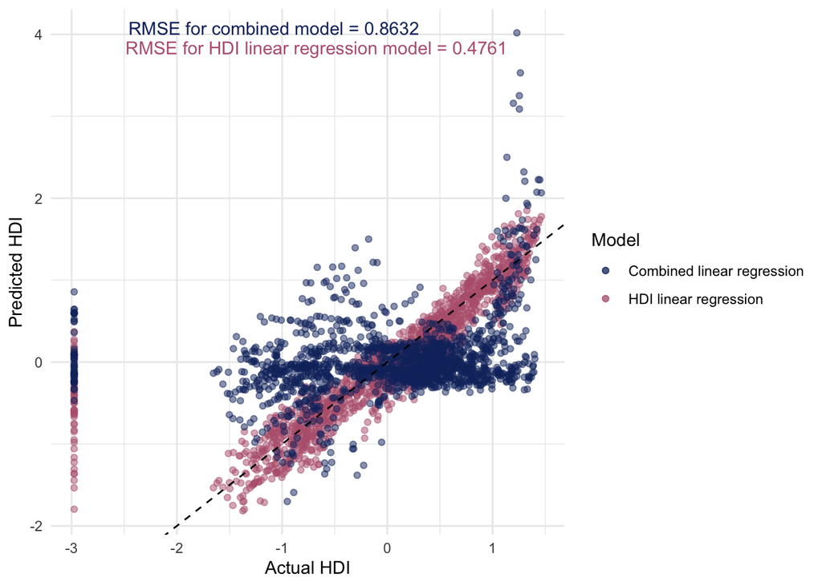

### Question 2

| Status | Predicted Error | Actual Error |
| --- | --- | --- |
| Model 1 - full model | 0.0673135 | 0.0667071 |
| Model 2 - full model + two way interactions | 0.0521528 | 0.0327471 |
| Model 3 - health related variables | 0.0673135 | 0.0661007 |
| Model 4 - economic related variables | 0.1267435 | 0.1255306 |

> Additionally, we decided to look into whether there is a difference in prediction errors between developed and developing countries. We ran 10 k-fold cross validation to gather predictions and divided predictions into two groups based on their development status. Next, we calculated the proportion of correct predictions for each development status in order to plot prediction errors. Wen repeated the process for all four models and used `facet_wrap` to put the four plots next to each other for comparison. The plot below suggests that prediction errors for developed countries are significantly higher compared to developing countries for all four models. We believe that the difference in prediction error is due to the large difference in sample sizes for developed and developing countries (242 and 1407 observations respectively). Developing countries are expected to have lower prediction errors as a result of having a larger sample size than the developed countries.

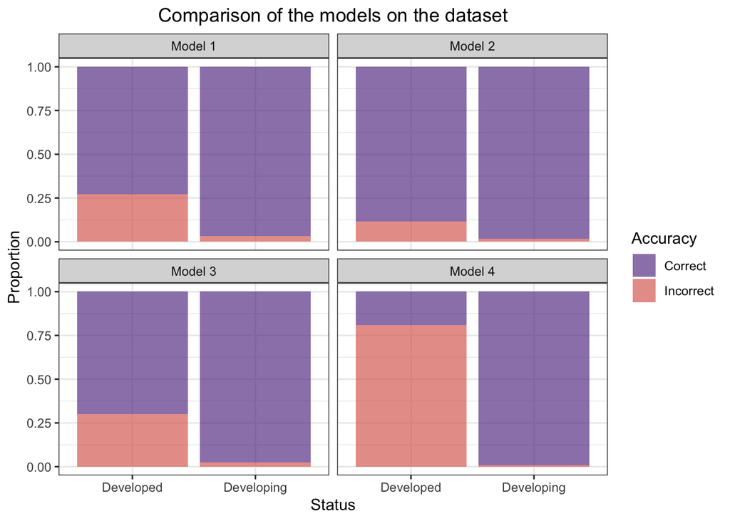

> Finally, we decided to compare prediction errors among the four models as shown in the plot above to examine the ability to predict development status using different sets of predictors. Using the full model as the benchmark, we observed that adding two-way interaction improved the model and reduced prediction errors regardless of the development status. Comparing model 1 (the base model) against model 3, we observed that using only health-related variables as predictors did not have a significant impact on reducing prediction errors. However, model 4, using only money-related variables as predictors, displayed the most interesting plot that was worth further investigation. Compared to the benchmark, model 4 significantly increased prediction errors for developed countries while decreasing prediction errors for developing countries. This indicates that money-related variables are good predictors for developing countries but not so much for developed countries. We believe this observation can be explained by the differences between developing and developed countries. While economic consideration is a significant factor, it is not the only factor important to assessing a country’s development status. Therefore, money-related variables are good at accurately predicting developing countries because limited economic resources indicate the country is still developing in most cases. Conversely, ample economic resources and high GDP per capita do not necessarily indicate that a country is considered developed as many other factors, including healthcare and education, need to be considered. This observation further indicates the importance of health factors, including life expectancy, in evaluating the overall development status.

## Conclusion:

> Our first question explored the predictive value between GDP and Life Expectancy on a country’s Human Development Index. We hypothesized that combining models used to predict GDP and Life Expectancy would create an accurate prediction of HDI. However, that wasn’t the case. Our two versions of combined models (3-way interaction and simple linear regression) produced predictions that hovered around the mean value of HDI - 0 when using standardized variables. This indicates that our combined model didn’t put enough emphasis on crucial variables required to accurately predict HDI. That being said, this is a somewhat expected finding because it shows that Human Development Index is more complex than just combining GDP and Life Expectancy. It is commendable that the Human Development Index recognizes the need for a comprehensive approach to measuring human development, one that takes into account not just economic and health factors, but also education, gender equality, and other social factors that contribute to a high quality of life. Advancing humanity across the globe requires us to look at more complicated and multifaceted metrics rather than simply equating a county’s GDP or Life Expectancy with quality of life.

> For our second question, we investigated how well the development status of a country can be predicted by other variables in the dataset. The differences in prediction accuracy when grouping different variables together enabled us to further examine the role they play in assessing the overall development of a country. After constructing four models, each with different sets of variables and comparing prediction errors against one another, we concluded that adding two-way interactions provided the lowest prediction errors and thus, the best model. The most insightful finding, however, was that model 4 - with only economic variables - performed the best at accurately predicting developing countries, while performing the worst at predicting developed countries. Our hypothesis for this observation is that economic growth has diminishing effects on improving a country’s development status. In other words, economic factors alone are not enough for a developing country to become developed. However, having inadequate economic standing automatically disqualifies a country from being eligible for developed status. We believe this insight is crucial for policymakers to understand so that resources can be allocated more efficiently for more holistic policies. As developing countries try to speed up the process as much as possible, economic growth is often a priority for policymakers while drafting policies and making investments. However, it is also important to look into other areas, including life expectancy and education, so that the development process can be more robust and efficient.

> Our research project effectively explores the relationship between Life Expectancy, GDP, and the overall development of a country. We were also able to develop a better understanding of how different variables interact with each other in our models. Similar to economic growth, life expectancy alone is not sufficient for a holistic assessment of how developed a country is. The purpose of our project is to promote broader awareness of how important it is for policymakers to think beyond the status quo to create more effective development plans. At the same time, our project can be used as a foundation for further research when more variables are added to the dataset. In the future, it would be interesting to investigate the mental health of different countries across the world because that would add another layer of depth to this conversation. Does higher wealth equate to happier countries? Are the people who live in developing countries struggling with mental health the same way people are in America? Those are just a couple of the infinite questions that could be asked if we had access to mental health data alongside the dataset we utilized.